# Functions

## Functions and plotting

### Defining functions

The basic syntax for defining more complex functions in Julia is `function fname(params) ... end`. Functions will be called in the traditional `f()` syntax. Functions are first class objects and can be passed with, e.g., `g = f`.  
Functions will return the last evaluated expression. The `return` keyword causes the function to return immediately. Multiple values are returned as tuples.

```python
# sox(x) = sin(x) / x
function sox(x)
    sin(x) / x
end
```

```
sox (generic function with 1 method)
```

```python
sox(0.0)
```

```
NaN
```

```python
code_typed(sox, (Float64,))
# code_llvm(sox, (Float64,))
# code_native(sox, (Float64,))
```

```
1-element Array{Any,1}:
 :($(Expr(:lambda, {:x}, {{:_var0},{{:x,Float64,0},{:_var0,Float64,18}},{}}, :(begin  # In[1], line 3:
        _var0 = (GetfieldNode(Base.Math,:nan_dom_err,Any))((top(ccall))($(Expr(:call1, :(top(tuple)), "sin", GetfieldNode(Base.Math,:libm,Any)))::(ASCIIString,ASCIIString),Float64,$(Expr(:call1, :(top(tuple)), :Float64))::(Type{Float64},),x::Float64,0)::Float64,x::Float64)::Float64
        return (top(box))(Float64,(top(div_float))(_var0::Float64,x::Float64))::Float64
    end::Float64))))
```

Function arguments are passed by reference. Changes to mutuable objects (such as arrays) will be visible to the outside.  
Functions that change the internal state of (some of) their parameters should have names with a closing '!' (bang).

```python
A = {};
push!(A, 1); push!(A, [1, 2]); push!(A, "1, 2, 3")
```

```
3-element Array{Any,1}:
 1
  [1,2]
  "1, 2, 3"
```

**Anonymous functions** are available as, e.g., `x -> x * exp(x)` and can be *mapped* onto an array of (single) parameters.

```python
map(x -> x * exp(x), [1:5])
```

```
5-element Array{Float64,1}:
   2.71828
  14.7781
  60.2566
 218.393
 742.066
```

Julia functions can use the usual control flow elements: "forget the ':' and add an 'end' statement."  
`if ... elseif ... else ... end`, `for`- and `while`-loops, or `try ... catch` for exception handling --  
`continue` and `break` are statements to leave an inner loop.

```python
function agm(a, b)
    while a != b
        a, b = (a+b)/2.0, sqrt(a*b)
    end
    return a
end
```

```
agm (generic function with 1 method)
```

```python
agm(1.0, sqrt(2.0))  # Gauss' constant 1.19814023473559220744
```

```
1.1981402347355923
```

Julia functions can have *optional* and *keyword* arguments. Optional arguments are considered for method dispatch, keyword arguments *not*.  
Optional arguments can*not* be used with their name.  
Keyword arguments are separated from other arguments by a semicolon.

```python
function agm(a, b, tol = 1e-10)
    while abs(a - b) > tol
        a, b = (a+b)/2.0, sqrt(a*b)
    end
    return a
end
```

```
agm (generic function with 2 methods)
```

```python
agm(1.0, sqrt(2.0), 1e-05)
```

```
1.1981402347938772
```

Julia functions can have *vararg* parameters ...

### Plotting functions

There are several packages for function plotting and generating statistical graphs:

- **Winston** -- simple function plotting
- **Gaston** -- uses *GnuPlot*
- **GadFly** -- implements a *Grammar of Graphics* (as in R's ggplot2)
- **PyPlot** -- uses Python's *Matplotlib*

```python
using PyPlot
pyplot = PyPlot.plot
```

```
INFO: Loading help data...
```

```
plot (generic function with 1 method)
```

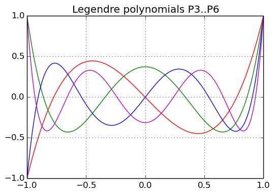

```python
x = linspace(-1, 1, 201);

figure(figsize=(6.0, 4.0));
pyplot(x, map(x->(5x^3-3x)/2, x), "r")
pyplot(x, map(x->(35x^4-30x^2+3)/8, x), "g")
pyplot(x, map(x->(63x^5-70x^3+15x)/8, x), "b")
pyplot(x, map(x->(231x^6-315x^4+105x^2-5)/16, x), "m")
title("Legendre polynomials P3..P6")
grid()
```

*Remark*: Only currently documented functions in `matplotlib.pyplot` are exported.

From a planned report on "Scientific Computing in Julia": Examples of Function Plotting